# LAB 2: ARIMA 모형 적합

모형식별, 모수추정, 모형진단(잔차분석)

## 예제 1

```r
> data(LakeHuron)
> LH <- LakeHuron
> LH
```

```
Time Series:
Start = 1875
End = 1972
Frequency = 1
 [1] 580.38 581.86 580.97 580.80 579.79 580.39 580.42 580.82 581.40 581.32
[11] 581.44 581.68 581.17 580.53 580.01 579.91 579.14 579.16 579.55 579.67
[21] 578.44 578.24 579.10 579.09 579.35 578.82 579.32 579.01 579.00 579.80
[31] 579.83 579.72 579.89 580.01 579.37 578.69 578.19 578.67 579.55 578.92
[41] 578.09 579.37 580.13 580.14 579.51 579.24 578.66 578.86 578.05 577.79
[51] 576.75 576.75 577.82 578.64 580.58 579.48 577.38 576.90 576.94 576.24
[61] 576.84 576.85 576.90 577.79 578.18 577.51 577.23 578.42 579.61 579.05
[71] 579.26 579.22 579.38 579.10 577.95 578.12 579.75 580.85 580.41 579.96
[81] 579.61 578.76 578.18 577.21 577.13 579.10 578.25 577.91 576.89 575.96
[91] 576.80 577.68 578.38 578.52 579.74 579.31 579.89 579.96
```

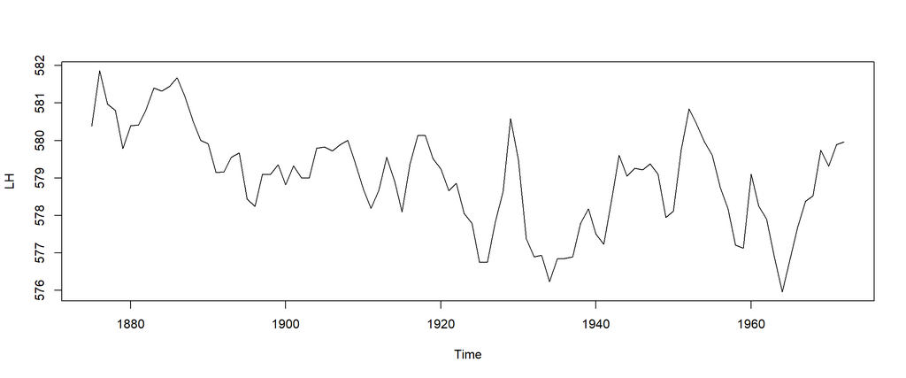

```r
> ts.plot(LH)
```

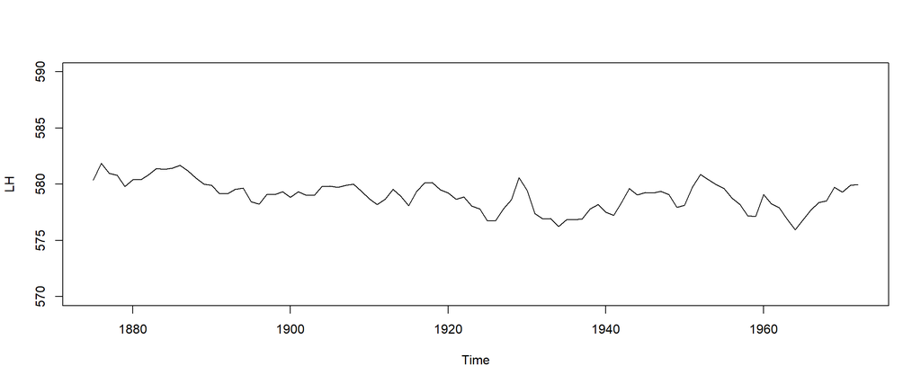

```r
> ts.plot(LH, ylim=c(570,590))
```

### Model identification

시계열분석에서의 모형식별은 주어진 자료에 적합한 시계열모형을 결정하는 것을 의미.  
SACF가 빠르게 감소하는 정상시계열의 경우는 ARMA모형으로 적합하기 때문에, 이 경우의 모형식별은 결국 ARMA모형의 차수 결정을 의미함. 차수의 결정은 시계열자료의 SACF와 SPACF를 보고 판단할 수 있으나, 많은 경우 SACF와 SPACF를 통하여 차수를 결정하는 것은 쉽지 않음. 대부분의 자료분석에서는 몇가지 후보모형(후보차수)을 선정한 후 AIC 또는 BIC의 값을 비교하여 차수를 잠정적으로 선택함.

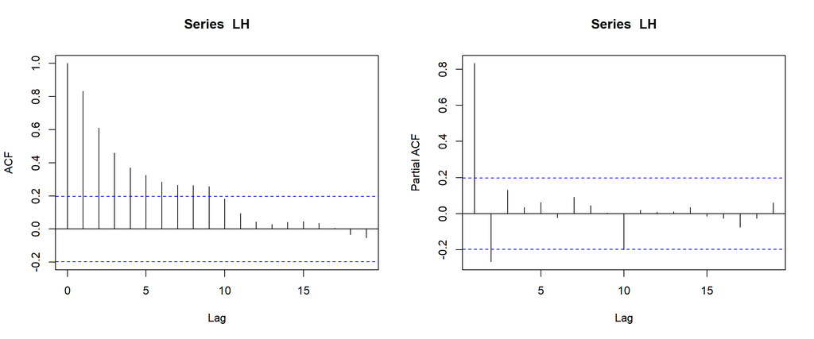

```r
> layout(t(1:2))
> acf(LH); pacf(LH)
```

Sample의 ACF가 빠르게 감소하고 PACF가 2차까지 유의하므로 AR(2)모형정도가 적절해 보임.  
AIC, BIC를 살펴보면 다음과 같음.

```r
> options(digits=5)
> for(p in 0:3) for(q in 0:3){
+   est<-arima(LH, order=c(p,0,q))
+   cat("p=",p, "q=",q, " AIC=", AIC(est), "BIC=",BIC(est) ,"\n")
+ }
```

```
p= 0 q= 0  AIC= 335.27 BIC= 340.44
p= 0 q= 1  AIC= 255.3 BIC= 263.05
p= 0 q= 2  AIC= 230.93 BIC= 241.27
p= 0 q= 3  AIC= 222.13 BIC= 235.05
p= 1 q= 0  AIC= 219.2 BIC= 226.95
p= 1 q= 1  AIC= 214.49 BIC= 224.83
p= 1 q= 2  AIC= 216.46 BIC= 229.39
p= 1 q= 3  AIC= 217.89 BIC= 233.4
p= 2 q= 0  AIC= 215.27 BIC= 225.61
p= 2 q= 1  AIC= 216.48 BIC= 229.4
p= 2 q= 2  AIC= 218.41 BIC= 233.92
p= 2 q= 3  AIC= 219.52 BIC= 237.61
p= 3 q= 0  AIC= 216.04 BIC= 228.96
```

```
p= 3 q= 1  AIC= 217.8 BIC= 233.31
p= 3 q= 2  AIC= 219.7 BIC= 237.79
p= 3 q= 3  AIC= 221.19 BIC= 241.87
```

```r
> aic<-1000
> for(p in 0:3) for(q in 0:3){
+   aic.tmp<-AIC(arima(LH, order=c(p,0,q)))
+   if(aic.tmp<aic){
+     aic<-aic.tmp
+     cat("p=",p, "q=",q, " AIC=",aic ,"\n")
+   }
+ }
```

```
p= 0 q= 0  AIC= 335.27
p= 0 q= 1  AIC= 255.3
p= 0 q= 2  AIC= 230.93
p= 0 q= 3  AIC= 222.13
p= 1 q= 0  AIC= 219.2
p= 1 q= 1  AIC= 214.49
```

AIC, BIC 모두 p=1, q=1일 때 최소가 되므로, ARMA(1,1)모형을 잠정모형으로 선택함.
$$(1-\phi B)(X_t - \mu)
= (1-\theta B)e_t$$
여기서 $\{ e_t\} \sim W.N\ (0,\sigma_e^2)$.

### Parameter estimation

잠정모형의 모수 $\phi, \theta, \mu$와 오차항의 분산 $\sigma_e^2$ 추정.

```r
> arima(LH, order=c(1,0,1))
```

```
Call:
arima(x = LH, order = c(1, 0, 1))

Coefficients:
        ar1    ma1  intercept
      0.745  0.321     579.05
s.e.  0.078  0.114       0.35

sigma^2 estimated as 0.475:  log likelihood = -103.25,  aic = 214.49
```

$\hat\phi=0.745,\ \hat\theta=-0.321,\ \hat\mu=579.05$이고 $\hat\sigma_e^2=0.475$.

### Model diagnostics

잠정모형이 주어진 자료에 적절한 모형인지 판단하는 단계.  
주로 잔차(residual)를 분석함으로써 이루어지는데, 잔차에 대하여 다음의 3가지를 확인함.  
1. 잔차가 0을 중심으로 퍼져있는가?  
2. 잔차의 분산이 시간과 관계없이 일정해 보이는가?  
3. 잔차의 선형관계(상관계가) 없어 보이는가/특별한 관계가 없어 보이는가?

일반적으로  
위 1과 2는 잔차의 plot을 보고 주관적으로 판단하게 됨.  
위 3은 잔차의 SACF와 SPACF를 보고 판단하거나 Ljung-Box검정을 통하여 판단함.  
(Ljung-Box검정의 귀무가설: 검정하고자하는 자료의에서특정시차까지의 ACF가 모두 0이다.)

본 예제에서는 우선 잔차의 ACF와 PACF를 보고 판단하기로 하자. 위 3가지를 확인한 결과 특별한 사항이 없으면 잠정모형을 확정하고 확정된 모형을 이용하여 예측을 하는 등 필요로하는 곳에 모형을 활용함.

```r
> fit<-arima(LH, order=c(1,0,1))
> r<-fit$residuals
```

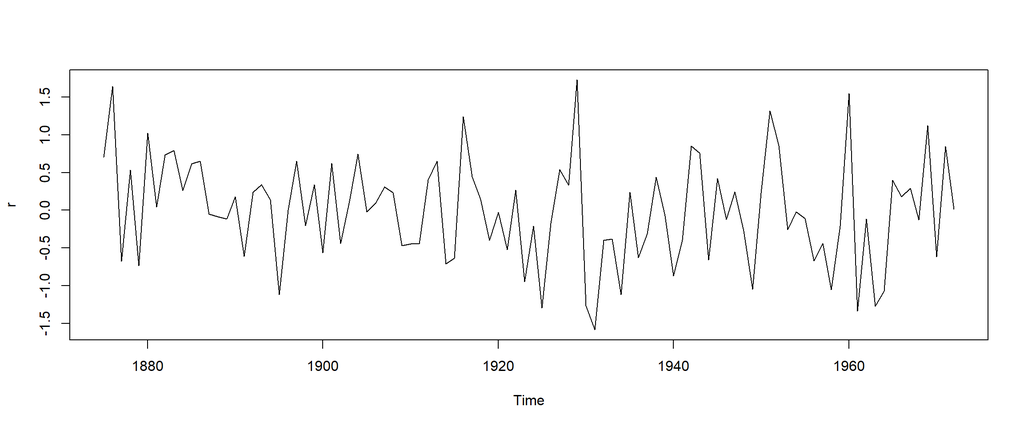

```r
> plot(r,type="l")
```

대략 0을 중심으로 일정한 범위 안에서 퍼져있는 것 같음. (위 1과 2에 대한 주관적 판단 결과)

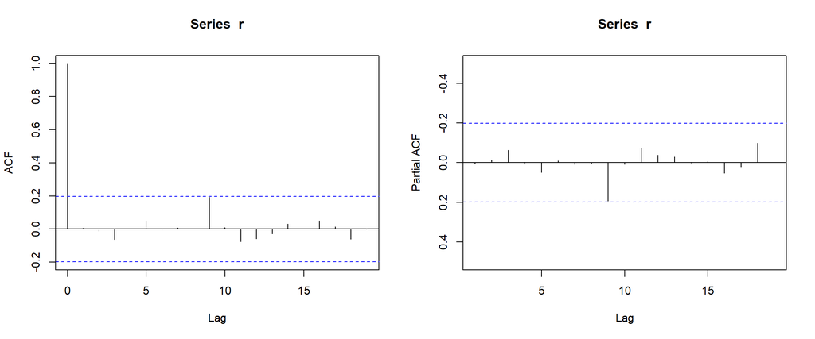

```r
> acf(r); pacf(r,ylim=c(0.5,-0.5))
```

white noise : 상관관계가 없음 $\Leftrightarrow$ ARMA모형으로 모형화할 선형종속관계가 없음.

위 잔차 plot과 잔차의 SACF와 SPACF를 살펴본 결과, 잠정모형 ARMA(1,1)모형은 주어진 시계열자료를 설명하는데 큰 무리가 없어보임. 따라서 ARMA(1,1)모형을 최종 모형으로 확정함.

```r
> Box.test(r, lag=6, type="Ljung-Box")
```

```
##
##  Box-Ljung test
##
## data:  r
## X-squared = 0.697, df = 6, p-value = 0.99
```

```r
> Box.test(r, lag=6, type="Ljung-Box", fitdf=2)
```

```
##
##  Box-Ljung test
##
## data:  r
## X-squared = 0.697, df = 4, p-value = 0.95
```

### Forecasting

최종모형을 이용하여 예측.

```r
> predict(fit, n.ahead=8)
```

```
$pred
Time Series:
Start = 1973
End = 1980
Frequency = 1
[1] 579.73 579.56 579.43 579.34 579.26 579.21 579.17 579.14

$se
Time Series:
Start = 1973
End = 1980
Frequency = 1
[1] 0.68916 1.00704 1.14599 1.21627 1.25356 1.27379 1.28487 1.29098
```

$pred: 예측치  
$se: 예측치에 대한 표준편차 (예측구간을 구할 때 사용됨.)  
많은 경우 $예측치 ± 2 × se$를 95% 예측구간으로 사용.

```r
> LH.fore<-predict(fit, n.ahead=20)
> LH.P<-LH.fore$pred
> LH.SE<-LH.fore$se
> LH.U<-LH.P+2*LH.SE
> LH.L<-LH.P-2*LH.SE
>
> cbind(LH.L,LH.P,LH.U)
```

```
Time Series:
Start = 1973
End = 1992
Frequency = 1
       LH.L   LH.P   LH.U
1973 578.36 579.73 581.11
1974 577.55 579.56 581.57
1975 577.14 579.43 581.72
1976 576.90 579.34 581.77
1977 576.76 579.26 581.77
1978 576.66 579.21 581.76
1979 576.60 579.17 581.74
1980 576.56 579.14 581.72
1981 576.53 579.12 581.71
1982 576.51 579.10 581.70
1983 576.50 579.09 581.69
1984 576.49 579.08 581.68
1985 576.48 579.08 581.67
1986 576.47 579.07 581.67
1987 576.47 579.07 581.66
1988 576.47 579.06 581.66
1989 576.46 579.06 581.66
1990 576.46 579.06 581.66
1991 576.46 579.06 581.66
1992 576.46 579.06 581.66
```

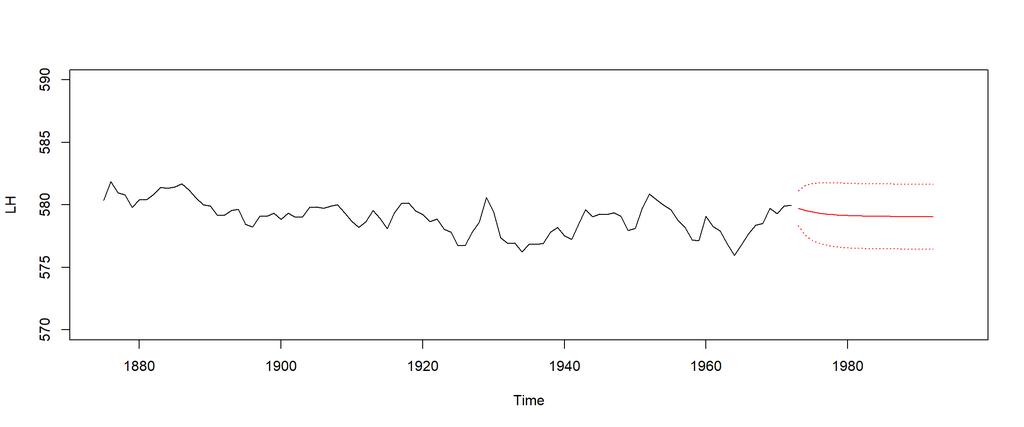

```r
> plot(LH, xlim=c(1875,1995), ylim=c(570,590))
> lines(LH.P,col="red")
> lines(LH.L,col="red", lty=3)
> lines(LH.U,col="red", lty=3)
```

## 예제 2

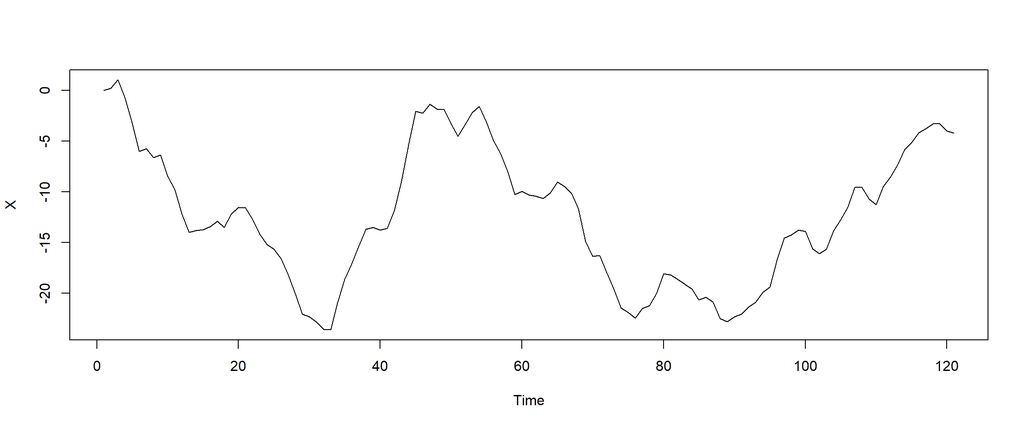

```r
> X<-read.table("c://ex2-2.txt", header=T)[,1]
> ts.plot(X)
```

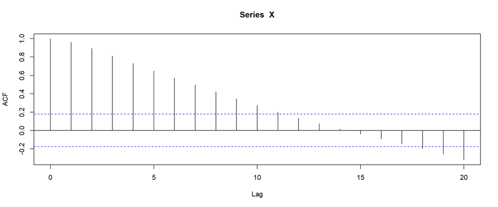

```r
> acf(X)
```

확률적인 추세를 보임 $\Rightarrow$ 차분을 통한 정상시계열 변환한 후 ARMA모형으로 적합. (즉, ARIMA모형으로)

특히, 결정적인 선형추세가 없어 보이므로, 상수항이 없는 ARIMA모형으로 적합하면 될 듯함.($\Leftrightarrow$ 차분된 확률과정이 기대값이 0인 ARMA모형)

위 예제 1에서처럼 차분된 자료 $\{\bigtriangledown X_t\}$에 대하여 최종 모형을 찾으면 됨.  
즉, $\{\bigtriangledown X_t\}$에 대하여 모형식별 $\Rightarrow$ 모수추정 $\Rightarrow$ 잔차분석을 통한 모형 진단을 거쳐 차분된 자료에 대한 최종모형 선정하면 됨.

### $\{\bigtriangledown X_t\}$에 대한 모형 식별

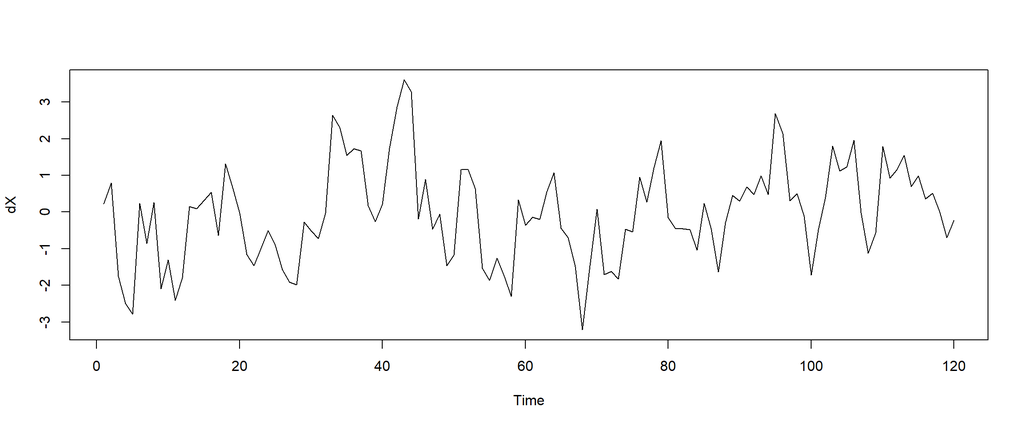

```r
> dX<-diff(X)
> ts.plot(dX)
```

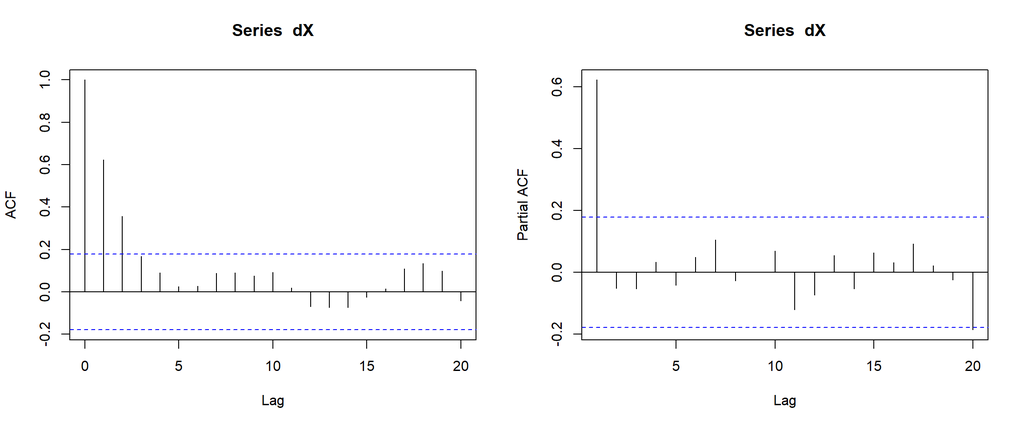

```r
> acf(dX); pacf(dX)
```

차분한 자료의 plot과 SACF 및 SPACF를 보면 $\{\bigtriangledown X_t\}$는 AR(1)모형이 적당할 듯.

```r
> aic<-1000
> for(p in 0:3) for(q in 0:3){
+   aic.tmp<-AIC(arima(dX, order=c(p,0,q)))
+   if(aic.tmp<aic){
+     aic<-aic.tmp
+     cat("p=",p, "q=",q, " AIC=",aic ,"\n")
+   }
+ }
```

```
p= 0 q= 0  AIC= 410.93
p= 0 q= 1  AIC= 369.91
p= 0 q= 2  AIC= 357.62
p= 1 q= 0  AIC= 354.5
```

AIC 또한 AR(1)모형을 추천. 따라서, $\{\bigtriangledown X_t\}$에 대한 잠정모형으로 AR(1)모형을 고려함. 원시계열 자료가 선형추세가 없으므로 기대값이 0인 AR(1)모형으로 예상되나 혹시나 해서 기대값이 0이 아닌 AR(1)모형을 고려함.
$$(1-\phi
B)(\bigtriangledown X_t-\mu) = e_t$$

### $\{\bigtriangledown X_t\}$에 대한 모수추정

```r
> arima(dX, order=c(1,0,0))
```

```
Call:
arima(x = dX, order = c(1, 0, 0))

Coefficients:
        ar1  intercept
      0.618     -0.034
s.e.  0.071      0.243

sigma^2 estimated as 1.06:  log likelihood = -174.25,  aic = 354.5
```

위에서 예상했던바와 같이 $\{\bigtriangledown X_t\}$는 기대값이 0인 정상 AR(1)모형으로 적합 가능할 듯함.

### 잔차분석을 통한 모형진단

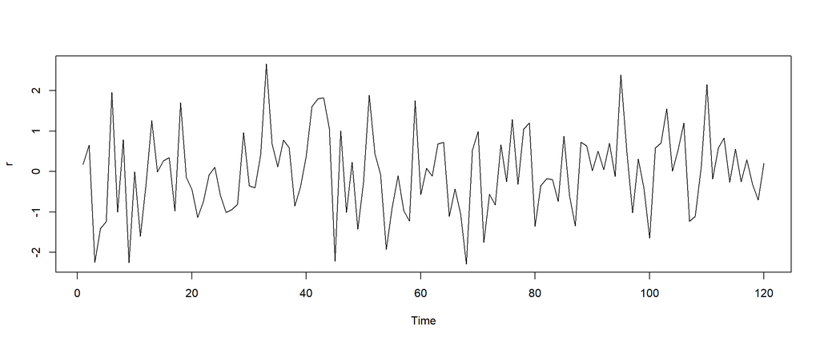

```r
> dX.fit<-arima(dX, order=c(1,0,0), include.mean = FALSE)
> r<-dX.fit$res
> plot(r)
```

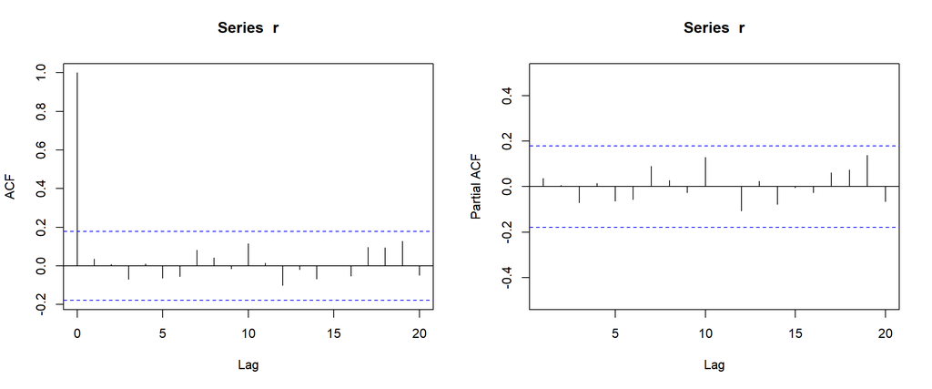

```r
> acf(r);pacf(r, ylim=c(-0.5,0.5))
```

잔차를 white noise로 보아도 무방할 듯.
따라서, 상수항이 없는 AR(1)모형을 $\{\bigtriangledown X_t\}$ 최종모형으로 확정함.
따라서, 다음의 상수항이 없는 ARIMA(1,1,0)모형을 원시계열자료 $\{X_t\}$에 대한 최종모형으로 결정함.
$$(1-\phi B)(1-B)X_t= e_t$$
여기서 $\{ e_t\} \sim W.N\ (0,\sigma_e^2)$.

```r
> arima(X, orde=c(1,1,0), include.mean=F)
```

```
Call:
arima(x = X, order = c(1, 1, 0), include.mean = F)

Coefficients:
        ar1
      0.618
s.e.  0.071

sigma^2 estimated as 1.06:  log likelihood = -174.26,  aic = 352.52
```

$\hat\phi=0.618,\ \hat\sigma_e^2=1.06$

```r
> arima(dX, orde=c(1,0,0), include.mean=F)
```

```
Call:
arima(x = dX, order = c(1, 0, 0), include.mean = F)

Coefficients:
        ar1
      0.618
s.e.  0.071

sigma^2 estimated as 1.06:  log likelihood = -174.26,  aic = 352.52
```

같은 결과임.

### 예측

```r
> fit<-arima(X, orde=c(1,1,0), include.mean=F)
> predict(fit, n.ahead=8)
```

```
$pred
Time Series:
Start = 122
End = 129
Frequency = 1
[1] -4.3528 -4.4399 -4.4938 -4.5271 -4.5477 -4.5604 -4.5683 -4.5731

$se
Time Series:
Start = 122
End = 129
Frequency = 1
[1] 1.0317 1.9626 2.8479 3.6654 4.4133 5.0977 5.7265 6.3076
```

예측시 원시계열자료에 대한 arima 명령어 결과를 이용해야 함.

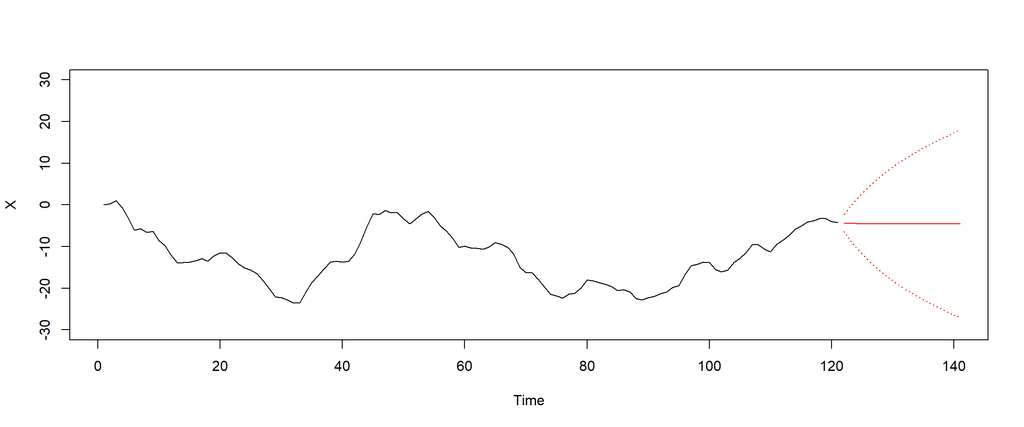

```r
> X.fore<-predict(fit, n.ahead=20)
> X.P<-X.fore$pred
> X.SE<-X.fore$se
> X.U<-X.P+2*X.SE
> X.L<-X.P-2*X.SE
>
> ts.plot(X,  xlim=c(1,140), ylim=c(-30,30))
> lines(X.P,col="red")
> lines(X.L,col="red", lty=3)
> lines(X.U,col="red", lty=3)
```

위 예제 1과는 달리 예측구간이 넓게 형성되어 있음. 이는 정상시계열(예제1)과 확률적추세를 갖는 시계열(예제2)의 차이에서 비롯됨.

정상시계열은 모든 시점에 대하여 기대값과 분산이 일정함. 이는 이후로도 이전과 동일한 수준과 분산을 가지고 값이 형성된다는 것을 의미함.

확률적 추세는 이후로 어떠한 형태(상승, 횡보, 하락, 상숭 후 하락, ….)든 가능하기 때문에, 예측구간이 넓게 형성됨. 또한, 예측치 X.fore$pred는 예측으로서 의미있는 값이 아님. 방향성을 예측할 수 없기 때문에 마지막에 관측된 값과 비슷한 값을 중심으로 나타남.